# BMI 881 literature seminar HW1

Tuo Wang

2019-10-02

The data has three categorical variable.

- `year`: 1990, 2005, 2010
- `age_group`: <75, >=75, all
- `income_group`: high, low and middle, all

## First attempt

To visualize the mortality values, I use `geom_point` for mortality rates and `geom_errorbar` for the confidence intervals. To show year, age and income, I could use `color` and `facet_wrap`. Because there are some points too closed to each other, I use `position_dodge` to let the point position deviating a little bit.

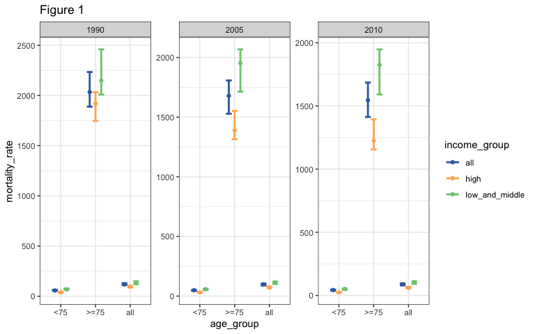

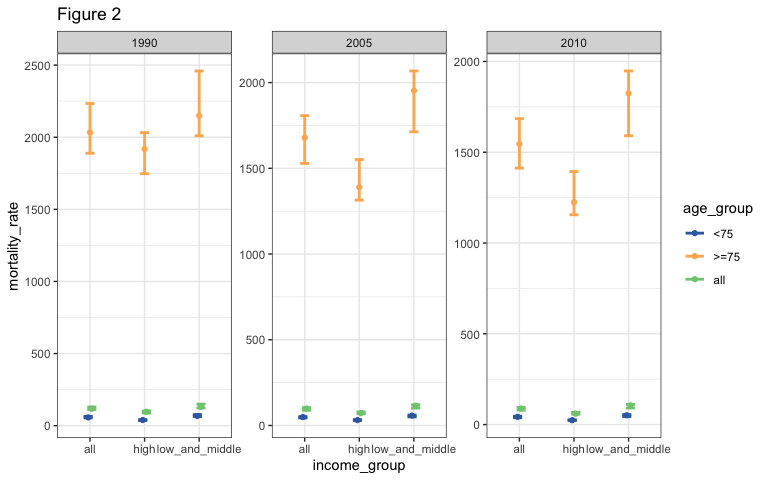

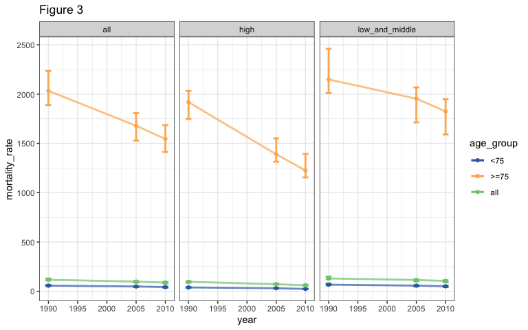